# INSTRUCTIONS

```r
# There are a lot movies with very little to zero votes, yet some few movies with a lot of votes. It might be smart to put the y-axis on a logarithmic scale to better visualize the distribution.
```

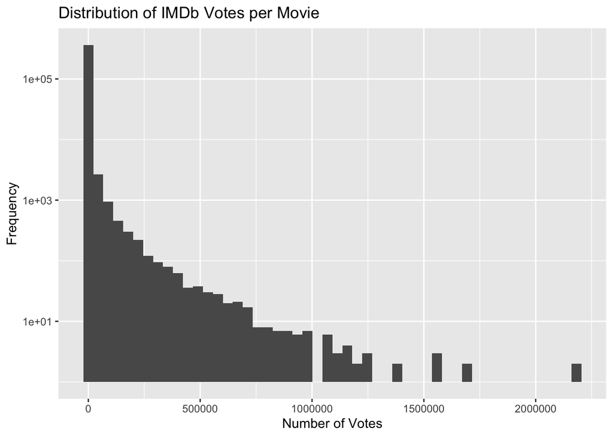

```r
ggplot(dt.unique.movies, aes(x = max_votes)) +
  geom_histogram(bins = 50) +
  labs(x = "Number of Votes", y = "Frequency", title = "Distribution of IMDb Votes per Movie") +
  scale_y_log10()
```

```r
# Get the top 5 entries
dt.unique.movies[order(-dt.unique.movies$max_votes), ][1:5, ]
```

```
##                              movie max_votes
##                             <char>     <num>
## 1: The Shawshank Redemption (1994)   2182052
## 2:          The Dark Knight (2008)   2165288
## 3:                Inception (2010)   1913848
## 4:               Fight Club (1999)   1742920
## 5:             Pulp Fiction (1994)   1714032
```

```r
# Masterpieces like The Shawshank Redemption (1994), The Dark Knight (2008) (both with over 2 million votes) or Inception (2010), Fight Club (1999), Pulp Fiction (1994) skew the histogram.
```

3. Plot a histogram that represents the distribution of the number of actors per movie. The x-axis should represent the number of actors and the y-axis should represent how many movies have x number of actors. Describe your findings. `[1 point]`

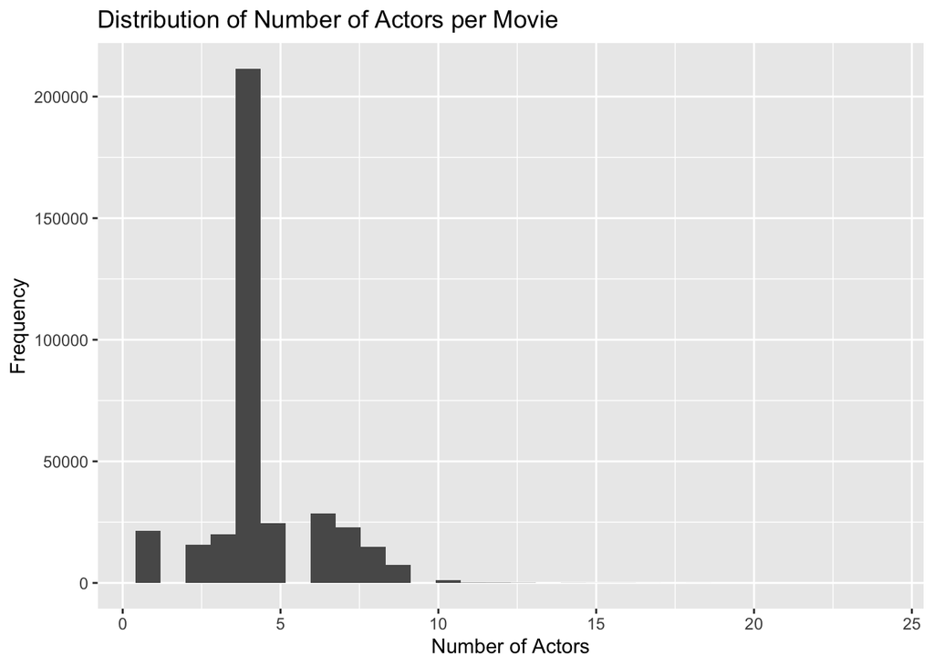

```r
dt.number.actor.movie <- dt.movie.actor[, .(number_of_actors = .N), by = movie]

ggplot(dt.number.actor.movie, aes(x = number_of_actors)) +
  geom_histogram() +
  labs(x = "Number of Actors", y = "Frequency", title = "Distribution of Number of Actors per Movie")
```

```r
# The histogram indicates that most movies have a small number of actors, with a peak at 4 actors per movie, suggesting that movies typically have a few leading roles. There is a rapid decline in the frequency of movies as the number of actors increases, highlighting that films with large casts are comparatively rare.
```

## Questions (`igraph`) `[10 points]`

1. From this question onwards, and until the end of the assignment, focus only on the actors that participated on the top 50 most popular movies from the 2010-2019 decade (by number of votes). Load the `igraph` package and create a bipartite graph in which the edges correspond to actors’ participation in movies. How many movie participations exist? `[1 point]`

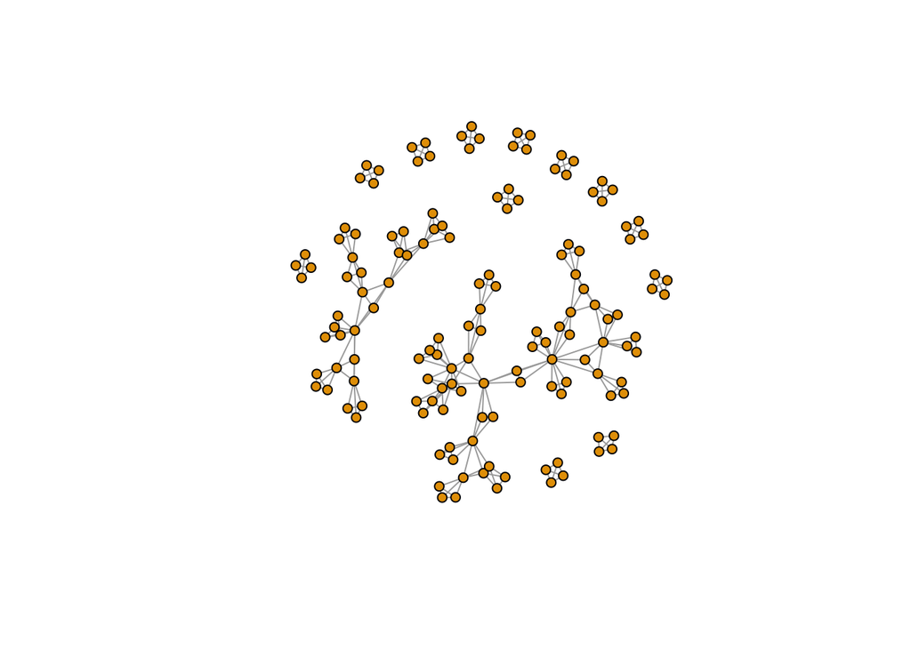

```r
library(igraph) # load the `igraph` library
# Create a graph with the top 50 most popular movies from the 2010-2019 decade
top50.movies <- dt.movie.actor[year >= 2010 & year <= 2019, .(max_votes = max(votes)), by = movie][order(-max_votes)][1:50, movie]

# Filter the data to include only the top 50 movies
dt.top50.actors <- dt.movie.actor[movie %in% top50.movies]

# Create a bipartite graph in which the edges correspond to actors’ participation in movies
dt.all.actors <- dt.top50.actors[, list(name=unique(actor), type=TRUE)]
dt.all.movies <- dt.top50.actors[, list(name=unique(movie), type=FALSE)]

dt.all.vertices <- rbind(dt.all.actors, dt.all.movies)
g.top50 <- graph.data.frame(dt.top50.actors[, list(movie, actor)], directed=FALSE, vertices=dt.all.vertices)
g.actors <- bipartite.projection(g.top50)$proj2
plot(g.actors, vertex.size=5, vertex.label=NA)
```

```r
# How many movie participations exist or i.o.w. how many edges does the graph have?
ecount(g.actors)
```

```
## [1] 271
```

```r
# There are 271 movie participations in the graph
```

2. Create a graph in which two movies are connected to each other if they have at least one actor in common. Calculate the degree centrality for each of the movies, and remove movies with no connections to other movies. Hint: the function `induced.subgraph` allows the creation of graphs with only a subset of the vertices. Calculate the following additional centrality measures for each of these movies: `[2 points]`
   - Closeness centrality
   - Betweenness centrality
   - Eigenvector centrality

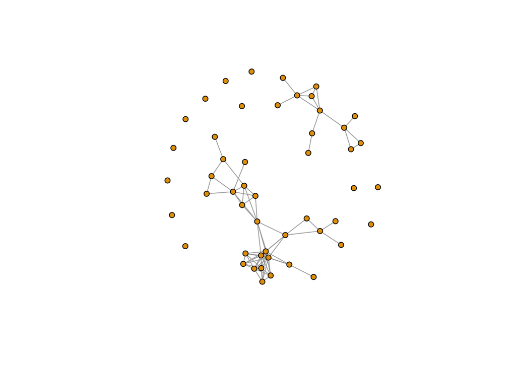

```r
# Create a graph in which two movies are connected to each other if they have at least one actor in common.
g.movies <- bipartite.projection(g.top50)$proj1

plot(g.movies, vertex.size=5, vertex.label=NA)
```

```r
# Calculate the degree centrality for each of the movies
V(g.movies)$degree <- degree(g.movies)
V(g.movies)$degree
```

```
##  [1]  1  2  5  0  0  5  1  5  8  4  7  4  0  0  0  4  6  6  1  3  3  1  2  1  4
## [26]  6  6  1  8 11  8 11 11  6  3  0  0  4  1  3  0  1  2  2  0  2  0  0  0  1
```

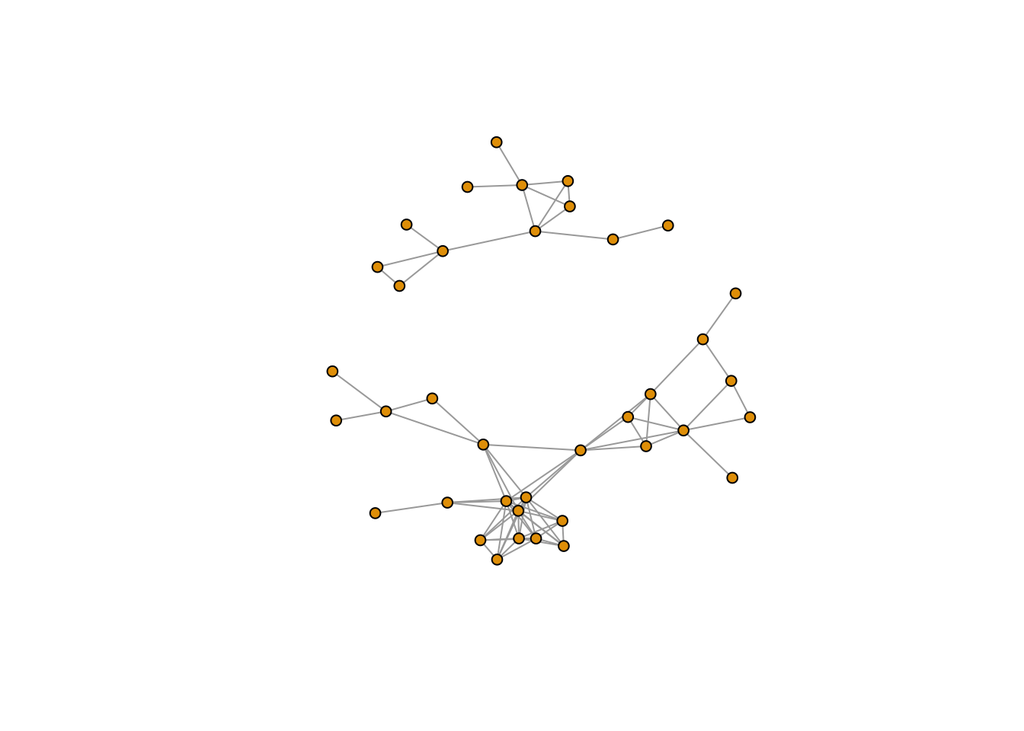

```r
# Remove the movies with no connections to other movies
g.movies <- induced.subgraph(g.movies, which(degree(g.movies) > 0))
# Plotting the graph
plot(g.movies, vertex.size=5, vertex.label=NA)
```

```r
# Calculate the following additional centrality measures for each of these movies: Closeness centrality, Betweenness centrality, Eigenvector centrality
V(g.movies)$closeness <- closeness(g.movies)
V(g.movies)$closeness
```

```
##  [1] 0.027777778 0.038461538 0.055555556 0.045454545 0.031250000 0.015873016
##  [7] 0.020408163 0.015384615 0.016129032 0.015384615 0.014285714 0.014705882
## [13] 0.014285714 0.008264463 0.012195122 0.012345679 0.010638298 0.012048193
## [19] 0.010309278 0.013698630 0.014705882 0.014705882 0.009433962 0.011494253
## [25] 0.019230769 0.011494253 0.019230769 0.019230769 0.018518519 0.040000000
## [31] 0.045454545 0.023809524 0.040000000 0.031250000 0.031250000 0.031250000
## [37] 0.013333333 0.011627907
```

```r
V(g.movies)$betweenness <- betweenness(g.movies)
V(g.movies)$betweenness
```

```
##  [1]   0.0000000  10.0000000  38.5000000  19.5000000   0.0000000  40.0000000
##  [7] 144.4285714   0.0000000  63.5000000   0.0000000  24.4285714  10.7619048
## [13]   0.4285714   0.0000000  24.5000000   4.0000000   0.0000000   0.0000000
## [19]   0.0000000  47.0000000  10.7619048  10.7619048   0.0000000   0.6000000
## [25]  45.5166667   0.6000000  45.5166667  45.5166667  84.4285714   0.0000000
## [31]  27.0000000   0.0000000   0.0000000   0.0000000   0.0000000   0.0000000
## [37]   0.0000000   0.0000000
```

```r
V(g.movies)$evcent <- evcent(g.movies)$vector
V(g.movies)$evcent
```

```
##  [1] 0.000000e+00 0.000000e+00 6.322597e-17 0.000000e+00 0.000000e+00
##  [6] 2.325598e-02 2.449395e-01 2.312831e-02 2.351178e-02 2.312831e-02
## [11] 2.215804e-01 4.101157e-01 5.101860e-01 2.888443e-03 1.865554e-03
## [16] 2.001946e-03 1.627764e-02 1.874278e-03 1.444221e-03 1.965956e-02
## [21] 4.299013e-01 4.299013e-01 1.370465e-04 7.811770e-01 1.000000e+00
## [26] 7.811770e-01 1.000000e+00 1.000000e+00 2.412304e-01 0.000000e+00
## [31] 0.000000e+00 0.000000e+00 0.000000e+00 0.000000e+00 0.000000e+00
## [36] 3.161299e-17 1.916538e-02 1.727212e-03
```

3. For each centrality measure, list the top 20 movies with highest centrality. How do you interpret the outcomes? `[2 points]`

```r
# Top 20 movies with highest degree centrality
V(g.movies)[order(-V(g.movies)$degree)][1:20]$name
```

```
##  [1] "Avengers: Age of Ultron (2015)"
##  [2] "Avengers: Infinity War (2018)"
##  [3] "Avengers: Endgame (2019)"
##  [4] "Shutter Island (2010)"
##  [5] "The Avengers (2012)"
##  [6] "Captain America: Civil War (2016)"
##  [7] "The Revenant (2015)"
##  [8] "Captain America: The First Avenger (2011)"
##  [9] "Captain America: The Winter Soldier (2014)"
## [10] "Iron Man 2 (2010)"
## [11] "Iron Man 3 (2013)"
## [12] "Now You See Me (2013)"
## [13] "X-Men: First Class (2011)"
## [14] "Silver Linings Playbook (2012)"
## [15] "The Wolf of Wall Street (2013)"
## [16] "Inception (2010)"
## [17] "Django Unchained (2012)"
## [18] "Thor (2011)"
## [19] "Batman v Superman: Dawn of Justice (2016)"
## [20] "X-Men: Days of Future Past (2014)"
```

```r
# Top 20 movies with highest closeness centrality
V(g.movies)[order(-V(g.movies)$closeness)][1:20]$name
```

```
##  [1] "X-Men: First Class (2011)"
##  [2] "Silver Linings Playbook (2012)"
##  [3] "X-Men: Days of Future Past (2014)"
##  [4] "The Hunger Games: Catching Fire (2013)"
##  [5] "The Hunger Games (2012)"
##  [6] "12 Years a Slave (2013)"
##  [7] "Joker (2019)"
##  [8] "Guardians of the Galaxy (2014)"
##  [9] "The Hobbit: An Unexpected Journey (2012)"
## [10] "The Hobbit: The Desolation of Smaug (2013)"
## [11] "World War Z (2013)"
## [12] "Logan (2017)"
## [13] "Shutter Island (2010)"
## [14] "Avengers: Age of Ultron (2015)"
## [15] "Avengers: Infinity War (2018)"
## [16] "Avengers: Endgame (2019)"
## [17] "Now You See Me (2013)"
## [18] "The Revenant (2015)"
## [19] "The Wolf of Wall Street (2013)"
## [20] "Inception (2010)"
```

```r
# Top 20 movies with highest betweenness centrality
V(g.movies)[order(-V(g.movies)$betweenness)][1:20]$name
```

```
##  [1] "Shutter Island (2010)"
##  [2] "Now You See Me (2013)"
##  [3] "The Revenant (2015)"
##  [4] "Batman v Superman: Dawn of Justice (2016)"
##  [5] "Avengers: Age of Ultron (2015)"
##  [6] "Avengers: Infinity War (2018)"
##  [7] "Avengers: Endgame (2019)"
##  [8] "The Wolf of Wall Street (2013)"
##  [9] "X-Men: First Class (2011)"
## [10] "X-Men: Days of Future Past (2014)"
## [11] "Interstellar (2014)"
## [12] "Thor (2011)"
## [13] "Silver Linings Playbook (2012)"
## [14] "Captain America: The First Avenger (2011)"
## [15] "Iron Man 2 (2010)"
## [16] "Iron Man 3 (2013)"
## [17] "12 Years a Slave (2013)"
## [18] "The Dark Knight Rises (2012)"
## [19] "The Avengers (2012)"
## [20] "Captain America: Civil War (2016)"
```

```r
# Top 20 movies with highest eigenvector centrality
V(g.movies)[order(-V(g.movies)$evcent)][1:20]$name
```

```
##  [1] "Avengers: Infinity War (2018)"
##  [2] "Avengers: Endgame (2019)"
##  [3] "Avengers: Age of Ultron (2015)"
##  [4] "The Avengers (2012)"
##  [5] "Captain America: Civil War (2016)"
##  [6] "Captain America: The Winter Soldier (2014)"
##  [7] "Iron Man 2 (2010)"
##  [8] "Iron Man 3 (2013)"
##  [9] "Captain America: The First Avenger (2011)"
## [10] "Shutter Island (2010)"
## [11] "Now You See Me (2013)"
## [12] "Thor (2011)"
## [13] "The Revenant (2015)"
## [14] "The Wolf of Wall Street (2013)"
## [15] "Inception (2010)"
## [16] "Django Unchained (2012)"
## [17] "Batman v Superman: Dawn of Justice (2016)"
## [18] "The Social Network (2010)"
## [19] "Black Swan (2010)"
## [20] "Man of Steel (2013)"
```

```r
# Interpretation of the outcomes:
# Generally speaking:
# - The top 20 movies with the highest degree centrality are those that have the most connections to other movies. Movies with high degree centrality like the Avengers movies, suggest that these films share a large number of actors with other movies.
#
# - The top 20 movies with the highest closeness centrality are those that are closest to all other movies in the network. High closeness centrality, as seen in 'X-Men: First Class' and 'The Hunger Games', implies that these movies can be reached quickly from any other movie in the network, suggesting that their actors are spread across various other movies, thereby reducing the 'distance'.
#
# - The top 20 movies with the highest betweenness centrality are those that are most central in the network, acting as bridges between other movies. A movie with high betweenness centrality, such as 'Shutter Island' or 'The Revenant', acts as a bridge in the network. This indicates these movies' actors connect otherwise less connected movies, making them central in linking different parts of the network.
#
# - The top 20 movies with the highest eigenvector centrality are those that are connected to other movies that are themselves well connected. Movies such as 'Avengers: Infinity War' and 'The Avengers' show high eigenvector centrality, indicating they not only have many connections but also are connected to other movies that are well connected, suggesting these movies are part of a core group of highly interconnected films.
#
# The presence of several Marvel films at the top of these lists is not surprising given the shared universe's model, where many actors appear across multiple films. Other movies with high centrality in these lists also tend to be part of franchises or have ensemble casts with actors who work in various high-profile films, increasing their connectivity in the network.
```

4. Calculate the average clustering coefficient for the movies network. `[1 point]`

```r
transitivity(g.movies, type="average")
```

```
## [1] 0.6551873
```

```r
# The average clustering coefficient for the movies network is 0.6551873.
```

5. Choose one movie you like and plot the movie, their direct neighbors and the links among them. What is the clustering coefficient of this movie? Which is the actor with most participations among these (neighbor) movies, but not having participated in the movie itself? `[2 points]`

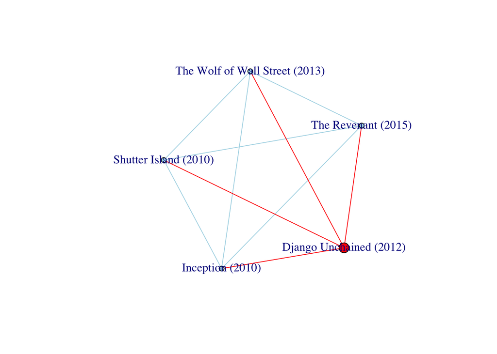

```r
movie.pick <- "Django Unchained (2012)"
neighbors.fav.movie <- neighbors(g.movies, V(g.movies)[name == movie.pick])$name

# Subsetting the graph to include only the movie and its neighbors
g.movies.fav.movie <- induced.subgraph(g.movies, c(movie.pick, neighbors.fav.movie))

# Plot the movie, their direct neighbors and the links among them
V(g.movies.fav.movie)$color <- ifelse(V(g.movies.fav.movie)$name == movie.pick, "red", "lightblue")
V(g.movies.fav.movie)$size <- ifelse(V(g.movies.fav.movie)$name == movie.pick, 10, 5)
E(g.movies.fav.movie)$color <- ifelse(get.edgelist(g.movies.fav.movie)[,1] == movie.pick | get.edgelist(g.movies.fav.movie)[,2] == movie.pick, "red", "lightblue")
plot(g.movies.fav.movie)
```

```r
transitivity(g.movies.fav.movie, type="local")
```

```
## The Wolf of Wall Street (2013)          Shutter Island (2010)
##                              1                              1
##               Inception (2010)            The Revenant (2015)
##                              1                              1
##        Django Unchained (2012)
##                              1
```

```r
# As this subgraph is a complete graph, the clustering coefficient of the movie "Django Unchained (2012)" (and all its direct neighbors) is 1.
```

```r
# The actor with most participations among these (neighbor) movies, but not having participated in the movie itself:

# Subsetting the top50.movies to only the movies in neighbors and movie.pick
dt.top50.actors.fav.neighbors <- dt.top50.actors[movie %in% c(movie.pick, neighbors.fav.movie)]

# Identifying actors playing in movie.pick
actors.movie.pick <- dt.top50.actors.fav.neighbors[movie == movie.pick, actor]

# Removing actors playing in movie.pick from top.50.actors.fav.neighbors
dt.actors.neighbors <- dt.top50.actors.fav.neighbors[!actor %in% actors.movie.pick, .N, by=actor][order(-N)]

dt.actors.neighbors
```

```
##                             actor     N
##                            <char> <int>
##  1:  Matthew McConaughey (b.1969)     1
##  2:         Ben Kingsley (b.1943)     1
##  3: Joseph Gordon-Levitt (b.1981)     1
##  4:            Tom Hardy (b.1977)     1
##  5:       Emily Mortimer (b.1971)     1
##  6:           Ellen Page (b.1987)     1
##  7:         Mark Ruffalo (b.1967)     1
##  8:         Ken Watanabe (b.1959)     1
##  9:           Jonah Hill (b.1983)     1
## 10:     Domhnall Gleeson (b.1983)     1
## 11:         Will Poulter (b.1993)     1
## 12:        Margot Robbie (b.1990)     1
```

```r
# There are multiple actors that have participated in the most neighbor movies, but not in the movie "Django Unchained (2012)". However, it is worth mentioning that "most neighbor movies" means 1 neighbor movie, as nobody played in "Django Unchained (2012)" and more than 1 neighbor movie.
```

6. Plot the degree distribution of the movies. How do you compare them with the degree distribution of a random graph? What can be plausible explanations for the observed differences? `[2 points]`

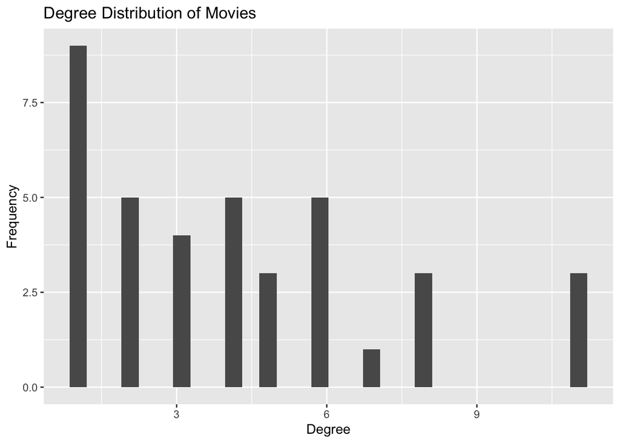

```r
# Plot the degree distribution of the movies
ggplot() + geom_histogram(aes(x = degree(g.movies))) + labs(x = "Degree", y = "Frequency", title = "Degree Distribution of Movies")
```

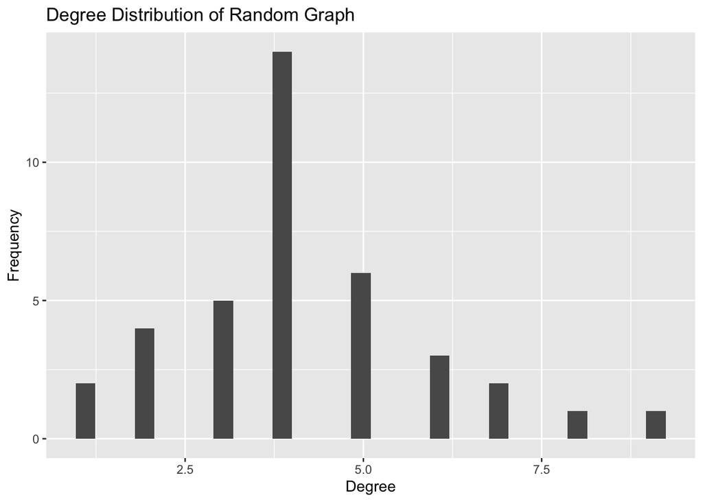

```r
# Generate a random graph with the same number of nodes and edges as g.movies
g.random <- sample_gnm(n=vcount(g.movies), m=ecount(g.movies))
ggplot() + geom_histogram(aes(x = degree(g.random))) + labs(x = "Degree", y = "Frequency", title = "Degree Distribution of Random Graph")
```

```r
# Movies, especially blockbusters and those belonging to franchises, often have casts that work together across multiple films. This creates a network with a higher-than-random clustering of connections, leading to the degree distribution being more varied and less uniform than in a random graph.
# Further, in real-world networks, new movies may prefer to attach to already popular movies or those with well-known actors. This 'rich-get-richer' phenomenon leads to a degree distribution that can follow a power law, unlike the more normal distribution expected in a random graph.
# Also, in the film industry, certain actors are cast together more frequently either due to typecasting, existing working relationships, or audience expectations. This can create a network where some movies are highly connected due to shared casts, while others are less so, unlike the random graph where the likelihood of such a pattern is low.
```